# Data wrangling with dplyr

POLI 210 - Seminar 8 live demo and reference

Author

Brad LeVeck

Published

October 21, 2026

# Before running the code

Open `poli210-seminar8.Rproj` in RStudio, then open this document. Keep the `data` and `R` folders beside it. Paths such as `data/ug.csv` are relative to this project folder, on both macOS and Windows. Do not use a path to the instructor’s computer or move the QMD away from its data.

Install these packages **once**, in the Console if needed:

```r
install.packages(c("dplyr", "tidyr", "readr", "stringr"))
```

Load packages and data **each new R session**. Run this setup before jumping to an example. The later join and reshape examples build on their preceding chunks. Rendering runs everything in order in a fresh session.

```r
library(dplyr)
library(tidyr)
library(readr)
library(stringr)

elections <- read_csv("data/elections.csv", show_col_types = FALSE)
ug <- read_csv("data/ug.csv", show_col_types = FALSE)
turk <- read_csv("data/mturk.csv", show_col_types = FALSE)
states <- read_csv("data/states.csv", show_col_types = FALSE)
members <- read_csv("data/house114.csv", show_col_types = FALSE)
options(width = 85, pillar.width = 85)
```

`read_csv()` is from **readr** and returns a tibble. `filter()` and the other data verbs are from **dplyr**; pivoting is from **tidyr**; text tools are from **stringr**. These packages belong to the tidyverse. `library(tidyverse)` is an alternative that loads these and several more packages.

No download is needed during class. The local CSVs are frozen teaching copies. `source("R/setup.R")` reloads the original input objects if you want to start over.

# 1. What does one row represent?

## The ultimatum game

`ug` contains 234 participants: 102 elites and 132 undergraduates. Each person provided a proposal and a minimum acceptable offer (MAO), when recorded. These are different choices by the same respondent, not an observed matched pair.

| Column | Meaning |
| --- | --- |
| `participant_id` | Teaching ID tied to a row in the source file |
| `population`, `elite` | Sample label; `elite` is 1 for elites and 0 for undergraduates |
| `mao`, `offer` | Minimum acceptable offer and proposed offer, on a 0–100 scale |
| `age` | Age in years |
| `levelk`, `patience` | Original reasoning and patience measures |
| `experience` | Experience in years, collected for elites only |

Unlike B2’s prepared file, this table **keeps missing MAOs** and additional variables. A zero MAO is a valid response, not missing. The original incentives involved lotteries; we continue to use the simplified 100-point interpretation.

```r
ug
```

```
# A tibble: 234 × 9
   participant_id population elite   mao offer   age levelk patience experience
   <chr>          <chr>      <dbl> <dbl> <dbl> <dbl>  <dbl>    <dbl>      <dbl>
 1 eu-0001        Elites         1    37    40    59      2       17         30
 2 eu-0002        Elites         1    40    50    53      1        8         30
 3 eu-0003        Elites         1    40    40    62      1        8         38
 4 eu-0004        Elites         1    49    50    57      0        7         32
 5 eu-0005        Elites         1     5    40    61      1        8         34
 6 eu-0006        Elites         1    50    50    67      0        5         40
 7 eu-0007        Elites         1    50    50    42      2       20         15
 8 eu-0008        Elites         1    40    50    56      0        0         20
 9 eu-0009        Elites         1    40    20    41      1        5         17
10 eu-0010        Elites         1    30    30    45      1        9         10
# ℹ 224 more rows
```

```r
glimpse(ug)
```

```
Rows: 234
Columns: 9
$ participant_id <chr> "eu-0001", "eu-0002", "eu-0003", "eu-0004", "eu-0005", "eu-0…
$ population     <chr> "Elites", "Elites", "Elites", "Elites", "Elites", "Elites", …
$ elite          <dbl> 1, 1, 1, 1, 1, 1, 1, 1, 1, 1, 1, 1, 1, 1, 1, 1, 1, 1, 1, 1, …
$ mao            <dbl> 37, 40, 40, 49, 5, 50, 50, 40, 40, 30, NA, 40, 35, 30, 1, 1,…
$ offer          <dbl> 40, 50, 40, 50, 40, 50, 50, 50, 20, 30, 50, 40, 50, 40, 50, …
$ age            <dbl> 59, 53, 62, 57, 61, 67, 42, 56, 41, 45, NA, 38, 61, 50, 37, …
$ levelk         <dbl> 2, 1, 1, 0, 1, 0, 2, 0, 1, 1, 0, 1, 1, 1, 0, 1, 1, 1, 1, 1, …
$ patience       <dbl> 17, 8, 8, 7, 8, 5, 20, 0, 5, 9, 10, 17, 5, 5, 6, 15, 8, 19, …
$ experience     <dbl> 30, 30, 38, 32, 34, 40, 15, 20, 17, 10, 40, 17, NA, 17, 13, …
```

```r
dim(ug)
```

```
[1] 234   9
```

```r
names(ug)
```

```
[1] "participant_id" "population"     "elite"          "mao"
[5] "offer"          "age"            "levelk"         "patience"
[9] "experience"
```

A tibble’s truncated display is not a subset of the data. `head()` displays a small subset; `as_tibble()` converts an ordinary data frame to a tibble.

```r
as_tibble(as.data.frame(ug)) %>% head(n = 3)
```

```
# A tibble: 3 × 9
  participant_id population elite   mao offer   age levelk patience experience
  <chr>          <chr>      <dbl> <dbl> <dbl> <dbl>  <dbl>    <dbl>      <dbl>
1 eu-0001        Elites         1    37    40    59      2       17         30
2 eu-0002        Elites         1    40    50    53      1        8         30
3 eu-0003        Elites         1    40    40    62      1        8         38
```

## The elections

`elections` has one row per retained district-election, 9,337 rows across 28 election years from 1946 through 2014. It is the selected CSV used in the old course, **not all House elections**. For example, it has 328 races in 2014, not 435. Some election years are absent. Do not interpret its mean as a national popular-vote share or its counts as national seat totals.

| Column | Meaning |
| --- | --- |
| `year`, `stcd` | Election year and original state-district code |
| `state` | State number in alphabetical order, **not FIPS or ICPSR** |
| `dv`, `dvp` | Democratic two-party House vote percentage, current/prior election |
| `dpres` | Democratic two-party presidential vote percentage; for midterms, two years earlier |
| `inc3` | 1 Democratic incumbent, −1 Republican incumbent, 0 no incumbent |
| `ptynow` | Party holding the seat before the election: 1 D, −1 R, 0 neither/new |
| `south` | 1 for an old-Confederacy state, 0 otherwise |
| `source_row` | Row in the local source CSV, not a substantive variable |

The original archive treats unopposed races as missing for `dv`. All `dv` and `dvp` values in this selected CSV are observed. Missing `dpres` values remain.

```r
elections %>% select(year, stcd, inc3, dv, dvp) %>% head()
```

```
# A tibble: 6 × 5
   year  stcd  inc3    dv   dvp
  <dbl> <dbl> <dbl> <dbl> <dbl>
1  1946   104     1  88.1  84.5
2  1946   107     1  72.7  65.9
3  1946   109     0  94.1  81.7
4  1946   405     1  85.2  87.1
5  1946   504     1  52.9  50.1
6  1946   507     0  43.8  57.9
```

```r
elections %>% count(year) %>% print(n = 30)
```

```
# A tibble: 28 × 2
    year     n
   <dbl> <int>
 1  1946   328
 2  1948   319
 3  1950   315
 4  1954   316
 5  1956   332
 6  1958   325
 7  1960   324
 8  1964   353
 9  1966   349
10  1968   342
11  1970   354
12  1974   347
```

[output cut: 16 more lines]

# 2. Verbs and pipes

## Keep rows with `filter()`

```r
filter(elections, year == 2014, inc3 == 0)
```

```
# A tibble: 37 × 10
   source_row  year  stcd ptynow  inc3    dv   dvp state south dpres
        <dbl> <dbl> <dbl>  <dbl> <dbl> <dbl> <dbl> <dbl> <dbl> <dbl>
 1       9012  2014   106     -1     0  23.7  28.7     1     1  25.0
 2       9022  2014   402     -1     0  45.7  41.7     4     1  44.0
 3       9023  2014   404     -1     0  44.2  38.1     4     1  36.8
 4       9031  2014   511      1     0  67.3  69.7     5     0  69.3
 5       9048  2014   545     -1     0  34.9  41.5     5     0  44.0
 6       9060  2014   604     -1     0  31.1  38.6     6     0  40.1
 7       9086  2014  1001     -1     0  39.1  37      10     1  43.5
 8       9092  2014  1101      1     0  51.9  54.6    11     0  70.6
 9       9123  2014  1501      1     0  48.9  57.8    15     0  56.9
10       9125  2014  1503     -1     0  44.5  45.5    15     0  52.1
# ℹ 27 more rows
```

Commas between conditions mean **AND**. Use `|` for OR and `%in%` for membership. Use `==` to compare values, not `=`. Column names are unquoted inside these verbs; literal text values are quoted.

```r
ug %>% filter(population == "Elites", mao >= 50) %>% head()
```

```
# A tibble: 6 × 9
  participant_id population elite   mao offer   age levelk patience experience
  <chr>          <chr>      <dbl> <dbl> <dbl> <dbl>  <dbl>    <dbl>      <dbl>
1 eu-0006        Elites         1    50    50    67      0        5         40
2 eu-0007        Elites         1    50    50    42      2       20         15
3 eu-0017        Elites         1    50    50    52      1        8         NA
4 eu-0019        Elites         1    50    50    65      1       20         25
5 eu-0022        Elites         1    50    50    63      1       16         32
6 eu-0024        Elites         1    50    15    49      0        0         21
```

```r
elections %>% filter(year %in% c(2010, 2014)) %>% head()
```

```
# A tibble: 6 × 10
  source_row  year  stcd ptynow  inc3    dv   dvp state south dpres
       <dbl> <dbl> <dbl>  <dbl> <dbl> <dbl> <dbl> <dbl> <dbl> <dbl>
1       8649  2010   102      1     1  48.9  50.3     1     1  37
2       8650  2010   103     -1    -1  40.5  45.9     1     1  43.4
3       8651  2010   105     -1     0  42.1  51.8     1     1  38.4
4       8652  2010   201     -1    -1  30.7  47.3     2     0  39.2
5       8653  2010   301      1     1  46.8  58.6     3     0  44.9
6       8654  2010   302     -1    -1  32.4  38.5     3     0  38.4
```

```r
ug %>% filter(mao < 20 | mao > 50) %>% head()
```

```
# A tibble: 6 × 9
  participant_id population elite   mao offer   age levelk patience experience
  <chr>          <chr>      <dbl> <dbl> <dbl> <dbl>  <dbl>    <dbl>      <dbl>
1 eu-0005        Elites         1     5    40    61      1        8         34
2 eu-0015        Elites         1     1    50    37      0        6         13
3 eu-0016        Elites         1     1    40    52      1       15         21
4 eu-0018        Elites         1     1    50    48      1       19         25
5 eu-0023        Elites         1     1    50    25      2       20          2
6 eu-0025        Elites         1     1    10    24      1       20          2
```

`filter()` keeps conditions that evaluate to `TRUE`. It drops both `FALSE` and `NA`. Test missingness with `is.na()`, never `mao == NA`.

```r
ug %>% filter(is.na(mao)) %>% select(participant_id, population, mao)
```

```
# A tibble: 6 × 3
  participant_id population       mao
  <chr>          <chr>          <dbl>
1 eu-0011        Elites            NA
2 eu-0042        Elites            NA
3 eu-0051        Elites            NA
4 eu-0064        Elites            NA
5 eu-0111        Undergraduates    NA
6 eu-0148        Undergraduates    NA
```

## Select and rename columns

```r
select(ug, participant_id, population, mao, offer) %>% head()
```

```
# A tibble: 6 × 4
  participant_id population   mao offer
  <chr>          <chr>      <dbl> <dbl>
1 eu-0001        Elites        37    40
2 eu-0002        Elites        40    50
3 eu-0003        Elites        40    40
4 eu-0004        Elites        49    50
5 eu-0005        Elites         5    40
6 eu-0006        Elites        50    50
```

```r
ug %>% select(-experience) %>% head(n = 2)
```

```
# A tibble: 2 × 8
  participant_id population elite   mao offer   age levelk patience
  <chr>          <chr>      <dbl> <dbl> <dbl> <dbl>  <dbl>    <dbl>
1 eu-0001        Elites         1    37    40    59      2       17
2 eu-0002        Elites         1    40    50    53      1        8
```

```r
elections %>%
  select(year, stcd, dv, dvp) %>%
  rename(dem_vote = dv, prior_dem_vote = dvp) %>%
  head()
```

```
# A tibble: 6 × 4
   year  stcd dem_vote prior_dem_vote
  <dbl> <dbl>    <dbl>          <dbl>
1  1946   104     88.1           84.5
2  1946   107     72.7           65.9
3  1946   109     94.1           81.7
4  1946   405     85.2           87.1
5  1946   504     52.9           50.1
6  1946   507     43.8           57.9
```

`rename(new_name = old_name)` retains other columns. `select()` chooses which columns remain. Printing either result does **not** overwrite the input.

## Read a pipe as “then”

```r
open_2014 <- elections %>%
  filter(year == 2014, inc3 == 0) %>%
  select(year, stcd, dv, dvp) %>%
  arrange(desc(dv))
open_2014
```

```
# A tibble: 37 × 4
    year  stcd    dv   dvp
   <dbl> <dbl> <dbl> <dbl>
 1  2014  2214  79.8  84
 2  2014  3312  75.3  79.6
 3  2014  2212  67.5  70.1
 4  2014   511  67.3  69.7
 5  2014  3813  67.1  69.1
 6  2014  4608  66.8  67.9
 7  2014  3012  62.5  70.1
 8  2014  3001  59.3  69.5
 9  2014  2106  57.2  50.6
10  2014  3204  52.8  65.7
# ℹ 27 more rows
```

`x %>% f(y)` usually means `f(x, y)`. The book uses `%>%`; the native R pipe `|>` works for these examples too. The assignment arrow saves the result.

## Sort versus choose the largest/smallest

```r
elections %>% filter(year == 2014) %>% arrange(dv) %>% head()
```

```
# A tibble: 6 × 10
  source_row  year  stcd ptynow  inc3    dv   dvp state south dpres
       <dbl> <dbl> <dbl>  <dbl> <dbl> <dbl> <dbl> <dbl> <dbl> <dbl>
1       9090  2014  1009     -1    -1  19.3  23.8    10     1  20.8
2       9248  2014  3603     -1    -1  21.4  21      36     0  26.1
3       9133  2014  1705     -1    -1  21.7  22.1    17     0  23.6
4       9284  2014  4301     -1    -1  22.5  27.4    43     1  27.8
5       9303  2014  4336     -1     0  22.5  27.3    43     1  26.0
6       9012  2014   106     -1     0  23.7  28.7     1     1  25.0
```

```r
elections %>% filter(year == 2014) %>% slice_max(dv, n = 3)
```

```
# A tibble: 3 × 10
  source_row  year  stcd ptynow  inc3    dv   dvp state south dpres
       <dbl> <dbl> <dbl>  <dbl> <dbl> <dbl> <dbl> <dbl> <dbl> <dbl>
1       9257  2014  3802      1     1  87.7  90.5    38     0  91.0
2       9199  2014  3010      1     1  87.1  89.2    30     0  88.4
3       9102  2014  1307      1     1  85.1  88.5    13     0  88.1
```

```r
elections %>% filter(year == 2014) %>% slice_min(dv, n = 3)
```

```
# A tibble: 3 × 10
  source_row  year  stcd ptynow  inc3    dv   dvp state south dpres
       <dbl> <dbl> <dbl>  <dbl> <dbl> <dbl> <dbl> <dbl> <dbl> <dbl>
1       9090  2014  1009     -1    -1  19.3  23.8    10     1  20.8
2       9248  2014  3603     -1    -1  21.4  21      36     0  26.1
3       9133  2014  1705     -1    -1  21.7  22.1    17     0  23.6
```

`arrange()` reorders all rows. `slice_max()`/`slice_min()` retain selected rows; ties are included by default, so `n = 3` can return more than three. `with_ties = FALSE` caps the result, but it does not provide a substantive reason to prefer one tied case. These are the largest/smallest Democratic vote percentages **in this selected sample**.

## Compute columns with `mutate()`

```r
elections_derived <- elections %>%
  mutate(
    dem_share = dv / 100,
    dem_swing = dv - dvp,
    distance_from_50 = abs(dv - 50),
    incumbent = inc3 != 0
  )
elections_derived %>%
  select(year, stcd, dv, dem_share, dem_swing, incumbent) %>% head()
```

```
# A tibble: 6 × 6
   year  stcd    dv dem_share dem_swing incumbent
  <dbl> <dbl> <dbl>     <dbl>     <dbl> <lgl>
1  1946   104  88.1     0.881      3.60 TRUE
2  1946   107  72.7     0.727      6.8  TRUE
3  1946   109  94.1     0.941     12.4  FALSE
4  1946   405  85.2     0.852     -1.90 TRUE
5  1946   504  52.9     0.529      2.80 TRUE
6  1946   507  43.8     0.438    -14.1  FALSE
```

`dem_share` is a proportion. `dem_swing` is a **percentage-point** change. Do not call `abs(dv - 50)` the two-candidate victory margin: that margin is `abs(2 * dv - 100)` percentage points. Neither is a causal incumbency effect.

## Conditional transformations

`mutate()` can create logical flags and readable categories, as well as arithmetic transformations. `if_else(condition, yes, no)` chooses a value for each row. `case_when()` checks alternatives in order; the first match wins.

```r
ug_flags <- ug %>% mutate(
  mao_missing = is.na(mao),
  offers_half_or_more = offer >= 50,
  sample_label = if_else(elite == 1, "Elite", "Undergraduate")
)
elections_labels <- elections %>% mutate(
  incumbent_party = case_when(
    inc3 == 1 ~ "Democratic incumbent",
    inc3 == -1 ~ "Republican incumbent",
    inc3 == 0 ~ "No incumbent",
    TRUE ~ NA_character_
  )
)
ug_flags %>% select(participant_id, mao, mao_missing, offers_half_or_more) %>% head()
```

```
# A tibble: 6 × 4
  participant_id   mao mao_missing offers_half_or_more
  <chr>          <dbl> <lgl>       <lgl>
1 eu-0001           37 FALSE       FALSE
2 eu-0002           40 FALSE       TRUE
3 eu-0003           40 FALSE       FALSE
4 eu-0004           49 FALSE       TRUE
5 eu-0005            5 FALSE       FALSE
6 eu-0006           50 FALSE       TRUE
```

These labels follow the source codebook, not an assumption that every numeric code has a self-evident meaning. `sample_label` is specific to the two-sample `ug` table: it would mislabel MTurk respondents if used after appending them.

## Missing responses and worst-case bounds

How much could the unobserved MAOs change the mean among **all 102 elites**? First check the data, rather than assuming which variable is missing:

```r
ug %>% group_by(population) %>% summarize(
  n_total = n(),
  missing_mao = sum(is.na(mao)),
  missing_offer = sum(is.na(offer)), .groups = "drop"
)
```

```
# A tibble: 2 × 4
  population     n_total missing_mao missing_offer
  <chr>            <int>       <int>         <int>
1 Elites             102           4             0
2 Undergraduates     132           2             0
```

Four elite MAOs are missing; elite offers are all observed. Two undergraduate MAOs are missing. For each variable, preserve observed values and replace only missing values by the endpoints of its allowed 0–100 range.

```r
ug_bounds <- ug %>% mutate(
  mao_lower = if_else(is.na(mao), 0, mao),
  mao_upper = if_else(is.na(mao), 100, mao),
  offer_lower = if_else(is.na(offer), 0, offer),
  offer_upper = if_else(is.na(offer), 100, offer)
)
ug_bounds %>%
  filter(elite == 1, is.na(mao)) %>%
  select(participant_id, mao, mao_lower, mao_upper, offer, offer_lower, offer_upper)
```

```
# A tibble: 4 × 7
  participant_id   mao mao_lower mao_upper offer offer_lower offer_upper
  <chr>          <dbl>     <dbl>     <dbl> <dbl>       <dbl>       <dbl>
1 eu-0011           NA         0       100    50          50          50
2 eu-0042           NA         0       100    40          40          40
3 eu-0051           NA         0       100    50          50          50
4 eu-0064           NA         0       100    61          61          61
```

`coalesce(x, replacement)` is a compact alternative: take `x` when observed, otherwise take the replacement. Thus `coalesce(mao, 0)` produces the same lower-bound variable. It is different from replacing every value by zero.

```r
stopifnot(identical(ug_bounds$mao_lower, coalesce(ug$mao, 0)))
elite_bounds <- ug_bounds %>% filter(elite == 1) %>% summarize(
  n_total = n(),
  n_observed = sum(!is.na(mao)),
  observed_mao_mean = mean(mao, na.rm = TRUE),
  full_sample_lower = mean(mao_lower),
  full_sample_upper = mean(mao_upper),
  offer_lower_mean = mean(offer_lower),
  offer_upper_mean = mean(offer_upper)
)
elite_bounds
```

```
# A tibble: 1 × 7
  n_total n_observed observed_mao_mean full_sample_lower full_sample_upper
    <int>      <int>             <dbl>             <dbl>             <dbl>
1     102         98              30.6              29.4              33.4
# ℹ 2 more variables: offer_lower_mean <dbl>, offer_upper_mean <dbl>
```

The observed-case MAO mean uses 98 people. Both bounds use all 102. If `m` responses are missing out of `N`, the full-sample mean lies in

$$\left[\frac{\sum_{i:\,M_i\text{ observed}} M_i}{N},
\quad \frac{\sum_{i:\,M_i\text{ observed}} M_i+100m}{N}\right].$$

For elites the bounds are about **29.4 to 33.4**, a width of `100 * 4 / 102`, or 3.92 points. The observed-case mean is about 30.6. Both offer bounds equal the observed offer mean, about 43.0, because there are no missing offers in this table.

These are **worst-case bounds for this finite sample**, assuming the missing values are in [0, 100] and observed values are correct. They are not confidence intervals, population bounds, or claims that anyone actually chose 0 or 100. We do not need to assume the responses are missing at random for these bounds. The original `mao` and `offer` columns remain unchanged.

We will return to `summarize()` and `group_by()` just below. **Try it then:** compute the same MAO bounds separately for elites and undergraduates. Which group has wider bounds, and how does that follow from its missing fraction?

## Unique values with `distinct()`

```r
ug %>% distinct(population)
```

```
# A tibble: 2 × 1
  population
  <chr>
1 Elites
2 Undergraduates
```

```r
elections %>% distinct(year, stcd) %>% nrow()
```

```
[1] 9337
```

```r
ug %>% distinct(mao) %>% nrow()
```

```
[1] 19
```

The last command counts distinct MAO values, including `NA`, **not people**. Never deduplicate participants just because they chose the same MAO.

**Try it:** Among the retained 2014 races, find the five closest to 50%. Show year, district code, Democratic vote percentage, and distance from 50%. Start from `elections_derived`; combine `filter()`, `slice_min()`, and `select()`.

# 3. Summaries, groups, and missing values

## Collapse to a summary row

```r
ug %>% summarize(mean_mao = mean(mao))
```

```
# A tibble: 1 × 1
  mean_mao
     <dbl>
1       NA
```

```r
ug %>% summarize(
  n_rows = n(),
  n_mao = sum(!is.na(mao)),
  n_missing = sum(is.na(mao)),
  mean_mao = mean(mao, na.rm = TRUE),
  sd_mao = sd(mao, na.rm = TRUE)
)
```

```
# A tibble: 1 × 5
  n_rows n_mao n_missing mean_mao sd_mao
   <int> <int>     <int>    <dbl>  <dbl>
1    234   228         6     27.1   17.1
```

`summarise()` and `summarize()` are the same function. `n()` counts rows, including rows with missing MAO. `na.rm = TRUE` uses observed values for that calculation; it does not delete rows or make nonresponse harmless.

## Repeat the same calculation within groups

```r
ug_summary <- ug %>%
  group_by(population) %>%
  summarize(
    n_rows = n(),
    n_mao = sum(!is.na(mao)),
    mean_mao = mean(mao, na.rm = TRUE),
    mean_offer = mean(offer, na.rm = TRUE),
    .groups = "drop"
  )
ug_summary
```

```
# A tibble: 2 × 5
  population     n_rows n_mao mean_mao mean_offer
  <chr>           <int> <int>    <dbl>      <dbl>
1 Elites            102    98     30.6       43.0
2 Undergraduates    132   130     24.5       38.7
```

Before: one row per participant. After: one row per population. Elite versus undergraduate status was not randomly assigned; this is a descriptive comparison. If you use `group_by(elite)` instead, the two groups are identical in `ug`.

## Grouping persists until removed

```r
year_incumbency <- elections %>%
  group_by(year, inc3) %>%
  summarize(n_races = n(), mean_dv = mean(dv))
group_vars(year_incumbency)
```

```
[1] "year"
```

```r
year_incumbency %>% slice_max(n_races, n = 1) %>% head()
```

```
# A tibble: 6 × 4
# Groups:   year [6]
   year  inc3 n_races mean_dv
  <dbl> <dbl>   <int>   <dbl>
1  1946    -1     156    36.7
2  1948    -1     207    46.4
3  1950     1     149    59.0
4  1954    -1     188    42.5
5  1956    -1     179    39.8
6  1958    -1     166    44.5
```

```r
year_incumbency %>% ungroup() %>% slice_max(n_races, n = 1)
```

```
# A tibble: 1 × 4
   year  inc3 n_races mean_dv
  <dbl> <dbl>   <int>   <dbl>
1  1948    -1     207    46.4
```

With one summary row per group, the default drops the last grouping variable, leaving `year`. Thus the first `slice_max()` finds a maximum **per year**. Use `ungroup()` or `.groups = "drop"` when subsequent operations should be global.

## Grouped `mutate()` preserves participant rows

```r
ug_centered <- ug %>%
  group_by(population) %>%
  mutate(
    group_mean = mean(mao, na.rm = TRUE),
    mao_centered = mao - group_mean
  ) %>%
  ungroup()
ug_centered %>% select(participant_id, population, mao, group_mean, mao_centered) %>% head()
```

```
# A tibble: 6 × 5
  participant_id population   mao group_mean mao_centered
  <chr>          <chr>      <dbl>      <dbl>        <dbl>
1 eu-0001        Elites        37       30.6         6.36
2 eu-0002        Elites        40       30.6         9.36
3 eu-0003        Elites        40       30.6         9.36
4 eu-0004        Elites        49       30.6        18.4
5 eu-0005        Elites         5       30.6       -25.6
6 eu-0006        Elites        50       30.6        19.4
```

`summarize()` makes group-level rows. `mutate()` adds group-based calculations to the original participant rows. Do not average group means without thinking about group sizes and the target population.

## Revisit B2’s empirical PMF

```r
mao_pmf <- ug %>%
  filter(!is.na(mao)) %>%
  count(population, mao, name = "frequency") %>%
  group_by(population) %>%
  mutate(probability = frequency / sum(frequency)) %>%
  ungroup()
mao_pmf %>% filter(mao %in% c(0, 25, 50))
```

```
# A tibble: 6 × 4
  population       mao frequency probability
  <chr>          <dbl>     <int>       <dbl>
1 Elites             0         1      0.0102
2 Elites            25         2      0.0204
3 Elites            50        17      0.173
4 Undergraduates     0         3      0.0231
5 Undergraduates    25         7      0.0538
6 Undergraduates    50        17      0.131
```

```r
mao_pmf %>% group_by(population) %>% summarize(total = sum(probability))
```

```
# A tibble: 2 × 2
  population     total
  <chr>          <dbl>
1 Elites             1
2 Undergraduates     1
```

`count(population, mao)` is a shortcut for grouped row counts. The denominator is the number of **observed MAOs within that population**, not all 234 people. Missingness is excluded explicitly for this empirical distribution.

**Try it:** Add an empirical CDF using `arrange(mao)` and `mutate(cdf = cumsum(probability))` *within each population*. Check that the final CDF value is 1. This is the same probability calculation as B2.

# 4. Character strings

The book’s string tools are handy for labels and inspection. They are not a substitute for a validated identifier when merging people.

```r
ca_names <- members %>% filter(state_abbrev == "CA") %>% select(icpsr, bioname)
ca_names %>% filter(str_detect(bioname, "SÁNCHEZ|PELOSI"))
```

```
# A tibble: 2 × 2
  icpsr bioname
  <dbl> <chr>
1 15448 PELOSI, Nancy
2 20310 SÁNCHEZ, Linda T.
```

```r
ca_names %>% mutate(surname = str_extract(bioname, "^[^,]+")) %>% head()
```

```
# A tibble: 6 × 3
  icpsr bioname           surname
  <dbl> <chr>             <chr>
1 15448 PELOSI, Nancy     PELOSI
2 15621 ROHRABACHER, Dana ROHRABACHER
3 20103 HONDA, Mike       HONDA
4 20104 SCHIFF, Adam      SCHIFF
5 20107 ISSA, Darrell     ISSA
6 20108 DAVIS, Susan A.   DAVIS
```

`|` means OR in this regular expression. `^` anchors the beginning; `[^,]+` matches one or more characters other than a comma. This extracts the text before the first comma; it is a display label, not a unique person ID.

The remaining tools in PSD §6.5, with real member names:

```r
name_examples <- ca_names$bioname[1:3]
length(name_examples)                 # Number of strings
```

```
[1] 3
```

```r
str_length(name_examples)             # Characters in each string
```

```
[1] 13 17 11
```

```r
str_count(name_examples, ",")         # Number of commas in each string
```

```
[1] 1 1 1
```

```r
str_extract(name_examples, "[A-Z]")   # First ASCII capital letter
```

```
[1] "P" "R" "H"
```

```r
str_extract_all(name_examples, "[A-Z]") # All matches: a list
```

```
[[1]]
[1] "P" "E" "L" "O" "S" "I" "N"

[[2]]
 [1] "R" "O" "H" "R" "A" "B" "A" "C" "H" "E" "R" "D"

[[3]]
[1] "H" "O" "N" "D" "A" "M"
```

```r
str_remove_all(name_examples, "[aeiou]") # A text operation, not name cleaning
```

```
[1] "PELOSI, Nncy"    "ROHRABACHER, Dn" "HONDA, Mk"
```

```r
str_split(name_examples, ",")         # List of vectors
```

```
[[1]]
[1] "PELOSI" " Nancy"

[[2]]
[1] "ROHRABACHER" " Dana"

[[3]]
[1] "HONDA" " Mike"
```

```r
str_split_fixed(name_examples, ",", n = 2) # Matrix with two columns
```

```
     [,1]          [,2]
[1,] "PELOSI"      " Nancy"
[2,] "ROHRABACHER" " Dana"
[3,] "HONDA"       " Mike"
```

```r
str_flatten(name_examples, collapse = "; ") # One display string
```

```
[1] "PELOSI, Nancy; ROHRABACHER, Dana; HONDA, Mike"
```

Do not treat `[A-Z]` as an inclusive definition of letters in names: accents, non-Latin scripts, suffixes, and naming conventions all matter. Nor does this extract-all example compute initials (the surnames here are uppercase).

Column-selection helpers can also match names:

```r
members %>% select(state_abbrev, bioname, matches("^nominate_")) %>% head()
```

```
# A tibble: 6 × 4
  state_abbrev bioname             nominate_dim1 nominate_dim2
  <chr>        <chr>                       <dbl>         <dbl>
1 AL           ROGERS, Mike Dennis         0.379         0.377
2 AL           SEWELL, Terri              -0.402         0.397
3 AL           ROBY, Martha                0.362         0.658
4 AL           BROOKS, Mo                  0.652        -0.417
5 AL           BYRNE, Bradley              0.61          0.25
6 AL           PALMER, Gary James          0.67          0.113
```

# 5. Changing the shape of a table

## Wide and long representations

The UG table is useful with one row per person and separate `mao` and `offer` columns. For a comparison across *choice types*, use one row per person-choice. Neither shape is inherently wrong: define the unit needed for the question.

```r
ug_long <- ug %>%
  select(participant_id, population, mao, offer) %>%
  pivot_longer(
    cols = c(mao, offer),
    names_to = "choice", values_to = "amount"
  )
ug_long %>% head(n = 8)
```

```
# A tibble: 8 × 4
  participant_id population choice amount
  <chr>          <chr>      <chr>   <dbl>
1 eu-0001        Elites     mao        37
2 eu-0001        Elites     offer      40
3 eu-0002        Elites     mao        40
4 eu-0002        Elites     offer      50
5 eu-0003        Elites     mao        40
6 eu-0003        Elites     offer      40
7 eu-0004        Elites     mao        49
8 eu-0004        Elites     offer      50
```

The column names become values of `choice`. Their contents become `amount`. There are now 468 rows, **still 234 people**. We retained missing amounts; `values_drop_na = TRUE` would remove those rows, which is not the same as zero.

```r
choice_summary <- ug_long %>%
  group_by(population, choice) %>%
  summarize(n_observed = sum(!is.na(amount)),
            mean_amount = mean(amount, na.rm = TRUE), .groups = "drop")
choice_summary
```

```
# A tibble: 4 × 4
  population     choice n_observed mean_amount
  <chr>          <chr>       <int>       <dbl>
1 Elites         mao            98        30.6
2 Elites         offer         102        43.0
3 Undergraduates mao           130        24.5
4 Undergraduates offer         132        38.7
```

## Widen a summary for presentation

```r
choice_summary %>%
  select(population, choice, mean_amount) %>%
  pivot_wider(id_cols = population, names_from = choice, values_from = mean_amount)
```

```
# A tibble: 2 × 3
  population       mao offer
  <chr>          <dbl> <dbl>
1 Elites          30.6  43.0
2 Undergraduates  24.5  38.7
```

Each population-choice key must identify one value. Do not ask `pivot_wider()` to silently average multiple people into one cell. Summarize first when that is the intended calculation. `values_fill = 0` is appropriate only when an absent combination means zero, not an unrecorded response or unknown mean.

Recover the person-level wide data without losing missingness:

```r
ug_wide_again <- ug_long %>%
  pivot_wider(id_cols = c(participant_id, population),
              names_from = choice, values_from = amount)
stopifnot(nrow(ug_wide_again) == nrow(ug))
```

# 6. Append observations with `bind_rows()`

`turk` has one row per MTurk respondent, with the repeated elite block already excluded. Align the common variables, then stack the observations:

```r
all_ug <- bind_rows(
  ug %>% select(participant_id, population, elite, mao, offer, age),
  turk %>% select(participant_id, population, elite, mao, offer, age)
)
all_ug %>% count(population)
```

```
# A tibble: 3 × 2
  population         n
  <chr>          <int>
1 Elites           102
2 MTurk           1007
3 Undergraduates   132
```

```r
all_ug %>% filter(!is.na(mao)) %>% count(population)
```

```
# A tibble: 3 × 2
  population         n
  <chr>          <int>
1 Elites            98
2 MTurk           1006
3 Undergraduates   130
```

The second count reproduces B2: 98 elites, 130 undergraduates, 1,006 MTurk respondents. Retaining missing MAOs yields 1,241 rows instead of B2’s 1,234.

`bind_rows()` adds observations and aligns columns by name. A join matches keys and attaches information. The original UG files have no validated shared participant ID for a general person-level join. Equal MAOs or equal row numbers across separate files are not evidence of a match.

After appending, `elite == 0` pools **two different comparison samples**. Use `population` when you want to keep undergraduates and MTurk separate.

# 7. Join elections to Voteview

## First a simple lookup

The source codebook defines `state` as alphabetical position among the 50 states. `states.csv` is the matching lookup from R’s state names/abbreviations. It is not a crosswalk between numeric FIPS and ICPSR codes.

```r
states %>% head()
```

```
# A tibble: 6 × 3
  state state_name state_abbrev
  <dbl> <chr>      <chr>
1     1 Alabama    AL
2     2 Alaska     AK
3     3 Arizona    AZ
4     4 Arkansas   AR
5     5 California CA
6     6 Colorado   CO
```

```r
elections_2014 <- elections %>%
  filter(year == 2014) %>%
  mutate(district = stcd %% 100, congress = 114) %>%
  left_join(states, by = "state", relationship = "many-to-one")
elections_2014 %>% select(year, state_name, district, dv) %>% head()
```

```
# A tibble: 6 × 4
   year state_name district    dv
  <dbl> <chr>         <dbl> <dbl>
1  2014 Alabama           2  32.6
2  2014 Alabama           3  33.8
3  2014 Alabama           6  23.7
4  2014 Alaska            1  44.6
5  2014 Arizona           1  52.6
6  2014 Arizona           2  50
```

`%% 100` takes the remainder after division by 100: `1304` becomes district 4. The 2014 election precedes the **114th Congress, 2015–2017**. We are describing the district’s subsequent representation, not its incumbent before the election.

## Check the keys before the substantive join

Voteview has one record per member appearance in a Congress. Some districts had replacements during the term. `state_abbrev + district_code` is therefore not necessarily unique, even after filtering to House members in Congress 114.

```r
duplicate_districts <- members %>%
  count(state_abbrev, district_code) %>%
  filter(n > 1)
duplicate_districts
```

```
# A tibble: 6 × 3
  state_abbrev district_code     n
  <chr>                <dbl> <int>
1 HI                       1     2
2 IL                      18     2
3 KY                       1     2
4 MS                       1     2
5 OH                       8     2
6 PA                       2     2
```

```r
members %>%
  filter(state_abbrev == "IL", district_code == 18) %>%
  select(bioname, nominate_dim1)
```

```
# A tibble: 2 × 2
  bioname       nominate_dim1
  <chr>                 <dbl>
1 SCHOCK, Aaron         0.311
2 LAHOOD, Darin         0.46
```

A raw left join illustrates the consequence:

```r
raw_join <- elections_2014 %>%
  left_join(members, by = c("congress", "state_abbrev", "district" = "district_code"))
c(before = nrow(elections_2014), after = nrow(raw_join))
```

```
before  after
   328    333
```

328 election rows become 333 matched rows. A left join retains every left observation, but **does not promise the same number of rows**. No warning is required for a one-to-many join. Repeating the election outcome gives those districts extra weight in later calculations.

## A conservative classroom rule

Keep a NOMINATE match only if exactly one member record is available for the district in that Congress. Leave ambiguous election rows unmatched; do not claim the person with the first row or largest score was the election winner.

```r
members_unique <- members %>%
  group_by(congress, state_abbrev, district_code) %>%
  filter(n() == 1) %>%
  ungroup() %>%
  select(congress, state_abbrev, district_code, icpsr, bioname, nominate_dim1)

joined <- elections_2014 %>%
  left_join(members_unique,
            by = c("congress", "state_abbrev", "district" = "district_code"),
            relationship = "many-to-one")

joined %>% select(year, state_abbrev, district, dv, bioname, nominate_dim1) %>% head()
```

```
# A tibble: 6 × 6
   year state_abbrev district    dv bioname             nominate_dim1
  <dbl> <chr>           <dbl> <dbl> <chr>                       <dbl>
1  2014 AL                  2  32.6 ROBY, Martha                0.362
2  2014 AL                  3  33.8 ROGERS, Mike Dennis         0.379
3  2014 AL                  6  23.7 PALMER, Gary James          0.67
4  2014 AK                  1  44.6 YOUNG, Donald Edwin         0.283
5  2014 AZ                  1  52.6 KIRKPATRICK, Ann           -0.169
6  2014 AZ                  2  50   MCSALLY, Martha             0.345
```

```r
stopifnot(nrow(joined) == nrow(elections_2014))
```

`relationship = "many-to-one"` checks that each left row matches at most one right row. It requires dplyr 1.1.0 or later. It does **not** check whether a match exists, whether the key is substantively correct, or whether a matched score is missing.

## Audit unmatched keys and missing measurements separately

```r
unmatched <- anti_join(elections_2014, members_unique,
                      by = c("congress", "state_abbrev", "district" = "district_code"))
unmatched %>% select(state_abbrev, district, dv)
```

```
# A tibble: 5 × 3
  state_abbrev district    dv
  <chr>           <dbl> <dbl>
1 HI                  1  51.9
2 IL                 18  25.3
3 KY                  1  26.9
4 MS                  1  29.9
5 PA                  2  87.7
```

```r
joined %>% summarize(
  rows = n(),
  no_member_match = sum(is.na(icpsr)),
  matched_but_missing_score = sum(!is.na(icpsr) & is.na(nominate_dim1))
)
```

```
# A tibble: 1 × 3
   rows no_member_match matched_but_missing_score
  <int>           <int>                     <int>
1   328               5                         0
```

The five unmatched election rows are the ambiguous districts HI-1, IL-18, KY-1, MS-1, and PA-2. The sixth duplicate district in Voteview, OH-8, is absent from the selected elections CSV. No election row was discarded by the safe join.

For another year, recheck the Congress, district boundaries, at-large coding, and duplicate records. Do not extrapolate this one-year merge automatically.

## Other join choices

```r
inner_result <- inner_join(elections_2014, members_unique,
                          by = c("congress", "state_abbrev", "district" = "district_code"))
semi_result <- semi_join(elections_2014, members_unique,
                        by = c("congress", "state_abbrev", "district" = "district_code"))
c(left = nrow(joined), inner = nrow(inner_result), semi = nrow(semi_result))
```

```
 left inner  semi
  328   323   323
```

| Join | What remains? |
| --- | --- |
| `left_join(x, y)` | Every left row, with right-side fields where keys match |
| `inner_join(x, y)` | Matched keys only; adds right-side fields |
| `right_join(x, y)` | Every right row, plus matching left-side information |
| `full_join(x, y)` | Keys from either side, with missing fields as needed |
| `semi_join(x, y)` | Left rows with a match, without adding right-side fields |
| `anti_join(x, y)` | Left rows without a match |

## Describe the merged data

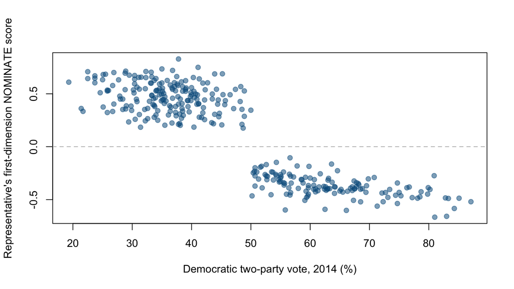

```r
plot_data <- joined %>% filter(!is.na(nominate_dim1))
plot(plot_data$dv, plot_data$nominate_dim1,
     xlab = "Democratic two-party vote, 2014 (%)",
     ylab = "Representative's first-dimension NOMINATE score",
     pch = 19, col = "#005a8b88")
abline(h = 0, col = "grey70", lty = 2)
```

This describes retained district elections and unambiguous subsequent member records. The first dimension broadly orders liberal–conservative roll-call positions; it is not an ideological scale for the district’s voters. The plot does not identify a causal effect of votes on ideology. NOMINATE values are estimates in the current frozen release, not forecasts available in 2014.

# 8. Save a result

Use a new filename rather than overwriting raw input:

```r
write_csv(joined, "elections-2014-with-nominate.csv")
```

Keep the script or QMD that produced it. An exported table alone does not record the exclusions, definitions, and join rules that created it.

# 9. Optional reference: the apply family

PSD §6.7 provides an alternative way to repeat calculations. You already used `replicate()` for repeated simulations. Here `apply()` works on rows or columns; `sapply()` applies a function to elements of a vector/list and tries to simplify.

```r
amounts <- as.matrix(select(ug, mao, offer))
apply(amounts, MARGIN = 2, FUN = mean, na.rm = TRUE)
```

```
     mao    offer
27.14474 40.59402
```

```r
# This repeats mean() for each column. MARGIN = 1 would operate per row.

offer_values <- c(20, 30, 40, 50)
acceptance <- sapply(offer_values, function(o) mean(ug$mao <= o, na.rm = TRUE))
tibble(offer = offer_values, acceptance,
       expected_payoff = (100 - offer_values) * acceptance)
```

```
# A tibble: 4 × 3
  offer acceptance expected_payoff
  <dbl>      <dbl>           <dbl>
1    20      0.425            34.0
2    30      0.583            40.8
3    40      0.794            47.6
4    50      0.987            49.3
```

The acceptance calculation pools the observed MAOs in these two samples, with weight proportional to sample size. It is not a population-weighted estimate for society. In a real analysis, choose and defend the population first.

Avoid `apply()` on a mixed numeric/character data frame: coercing it to a matrix can turn all columns into strings. `sapply()` can return different shapes depending on the results. `lapply()` always returns a list; `vapply()` lets you specify the expected output type. Those distinctions are reference material, not a second programming curriculum for today.

# Sources and help

- Reading: Speegle and Clair, [PSD Chapter 6](https://probstatsdata.com/datamanipulation.html).
- [dplyr introduction](https://dplyr.tidyverse.org/articles/dplyr.html), [grouping](https://dplyr.tidyverse.org/articles/grouping.html), and [join documentation](https://dplyr.tidyverse.org/reference/mutate-joins.html).
- [tidyr pivoting](https://tidyr.tidyverse.org/articles/pivot.html) and [stringr introduction](https://stringr.tidyverse.org/articles/stringr.html).
- Jacobson, Gary (2015), *It’s Nothing Personal: The Decline of the Incumbency Advantage in U.S. House Elections*, [replication archive](https://doi.org/10.7910/DVN/29559). The course CSV is a selected extract, checked against the aggregate archive.
- LeVeck et al. (2014), *The Role of Self Interest in Elite Bargaining*, [replication archive](https://doi.org/10.7910/DVN/27894). See `data/SOURCES.txt`.
- Lewis et al. (2026), [Voteview](https://voteview.com/), [member-file documentation](https://voteview.com/articles/data_help_members). Frozen download: October 20, 2026; teaching subset: House, Congress 114.

For an individual function, type `?filter`, `?pivot_longer`, or `?left_join` in the Console. If a different package masks a function, use its explicit name, such as `dplyr::filter()`.